# HW1

Sarper Karabağ

# Part 1 - EVDS Data Graph

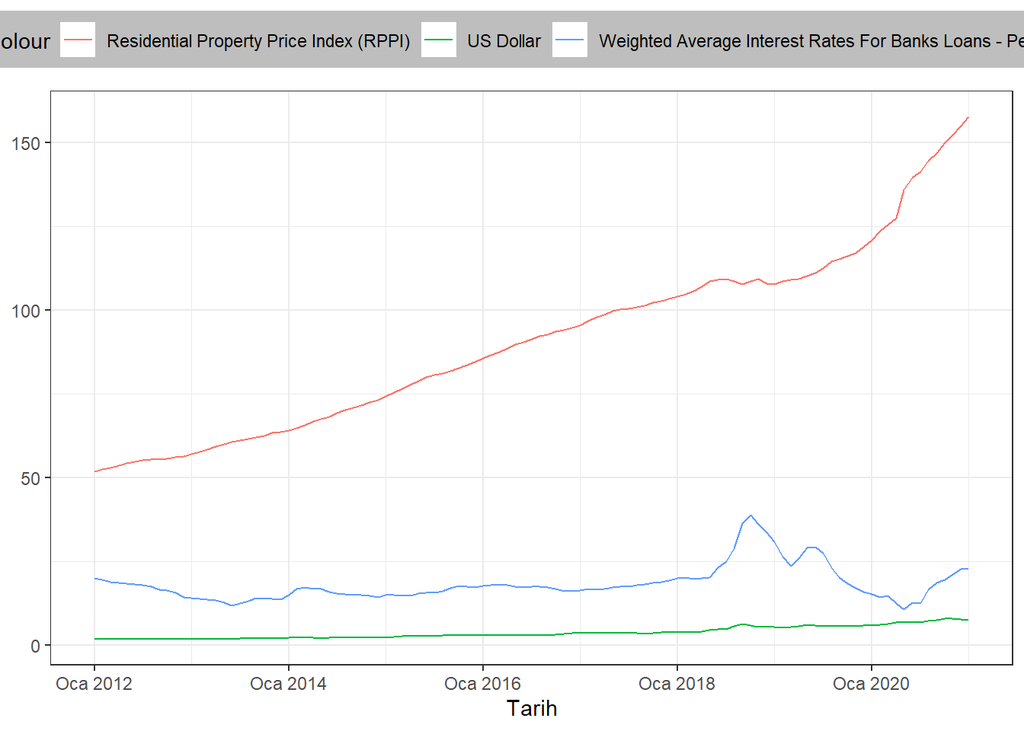

## Questions about the graph

### 2) Is there a quarterly or monthly similarity over the years?

In the last quarter of 2018 and first quarter of the2019

In late quarter of 2018 and in the late quarter of 2020.

### 3) Are there any abnormal observations?

In the late quarter of 2019 to early stages of 2020, we can observe an abnormality as normally 3 data behave similarly.

### 4) What may be the reason of the behavior you observed?

One reason might be the increase in the rent rates in the 2019 as %18,27.

# Part2 - Google Trend Data Visualization

## Key word: Konut Kredisi

### US Dollar - Konut Kredisi

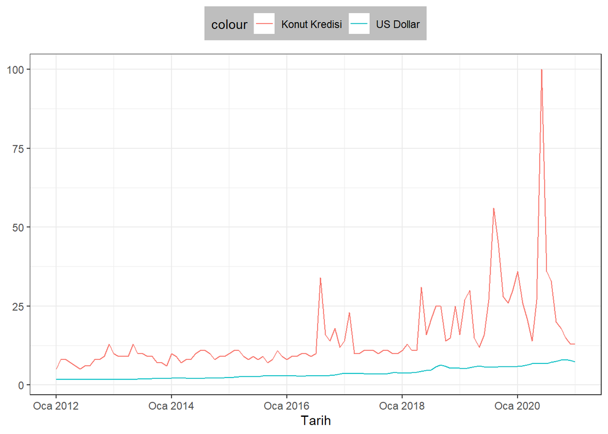

We can say that there is an increasing trend. When dollar price increases, mortgage increases. It can be observed after the first quarter of 2018.

### Weighted Average Interest Rates For Banks Loans(Personal) - Konut Kredisi

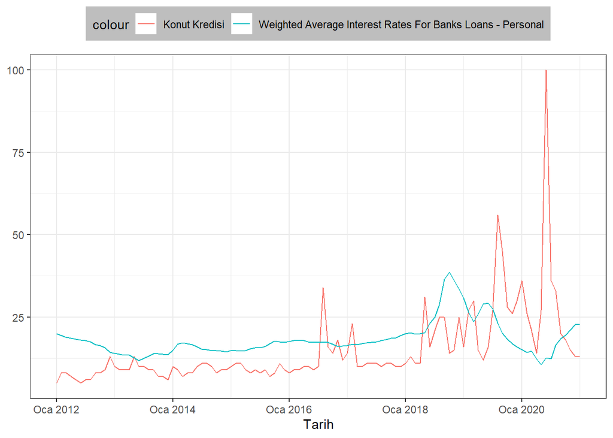

We can say that there is no certain trend but components are tend to behave opposite.

### Residential Property Price Index (RPPI) - Konut Kredisi

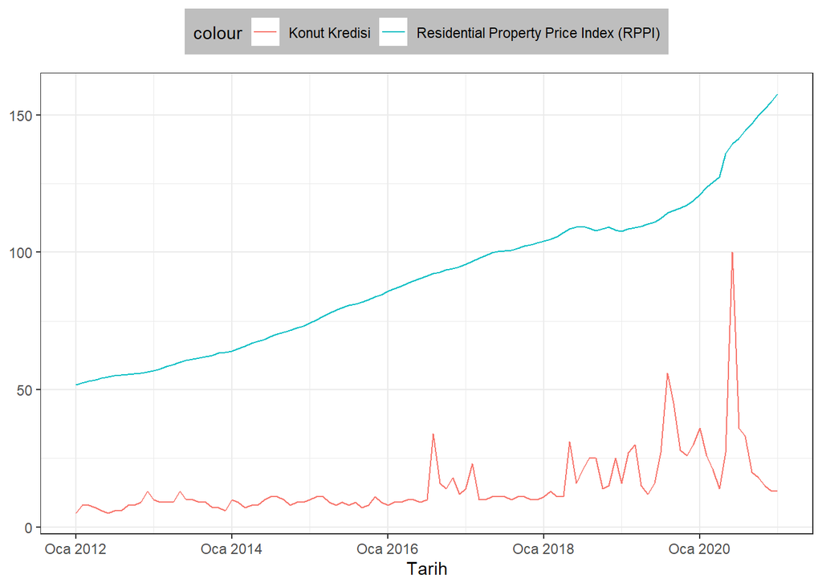